# Ford Go-Bive Exploration Analysis Summary

## Abdulmuiz Adebowale

## Investigation Overview

> In this inquiry, I wanted to look at how the length of journeys varies depending on DateTime and the type of customer. Hours of the day, days of the week, and customer type were given the most attention.

## Dataset Overview

> The information relates to over 183,000 trips taken in a bike-sharing program that serves the larger San Francisco Bay area. In addition to other variables like the member's year of birth, start and finish station names, start and end station longitude and latitude, start and end station unique id, and others, the data characteristics include duration (secs) and others like DateTime, customer type, and gender. A total of 8000 data points were dropped from the study because of errors or missing data.

## Frequency of Rides Per Day

Most rides were taken on Tuesdays and Thursdays. Saturday and Sunday have the lowest trip records.

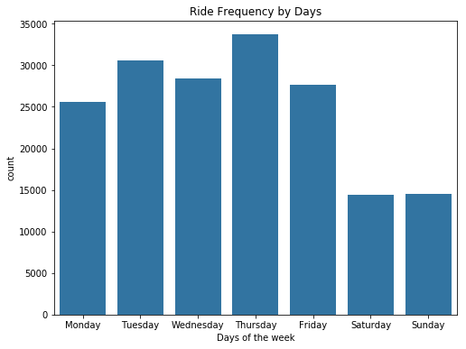

## Visualization for the amount of trips taken per hour

> The 8th, 9th, 17th, and 18th hours have the greatest trip records for the days as observed. This can be attributed to morning rush hour, so it is to be expected.

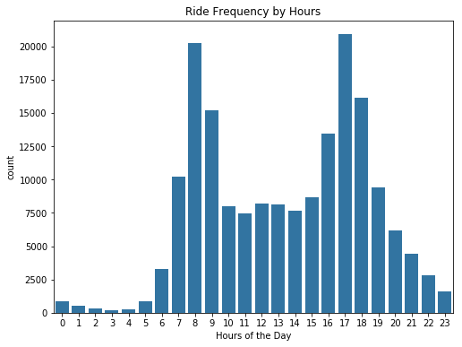

## Frequency of Rides Per Gender

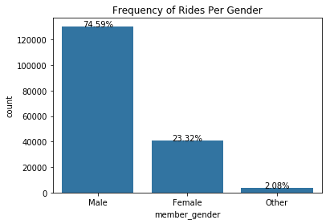

## Trip Length by Customer Type and Weekdays

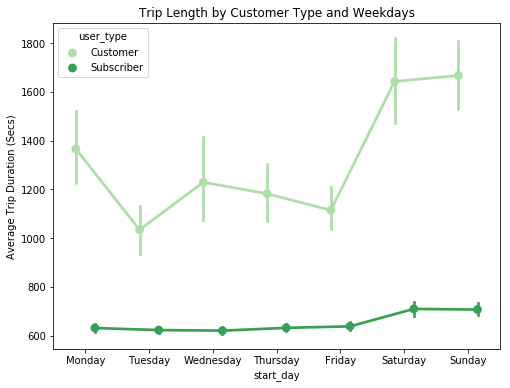